# Question 1

**The life in hours of a battery is known to be approximately normally distributed with standard deviation σ=1.25 hours. A random sample of 10 batteries has a mean life of $\bar{x}=40.5$ hours.**

**A. Is there evidence to support the claim that battery life exceeds 40 hours? Use $α=0.05$.**

**B. What is the P-value for the test in part A?**

**C. What is the β-error for the test in part B if the true mean life is 42 hours?**

**D. What sample size would be required to ensure that β does not exceed 0.10 if the true mean is 44 hours?**

**E. Explain how you could answer the question in part A by calculating an appropriate confidence bound on battery life.**

[figure not shown]

Image Source: https://phys.org/news/2015-04-history-batteries.html

## A. Is there evidence to support the claim that battery life exceeds 40 hours? Use α=0.05.

$H_0: \mu=40$

$\bar{x}=40.5$

$\sigma = 1.25$

$\alpha = 0.05$

$n=10$

*P-value*$< \alpha$*, then we reject* $H_0$

*P-value*$> \alpha$*, then we accept* $H_0$

$Z_0 > Z_{value}$*, then we reject* $H_0$

$Z_0 < Z_{value}$*, then we accept* $H_0$

We can look for the confidence level $C$

$$C = 1 - \alpha = 1 - 0.05 = 0.95$$

$$Z^2 = \frac{\alpha}{2} + C = 0.025 + 0.95 = 0.975$$

Look for $0.975$ on the table to look for the Z-Value.

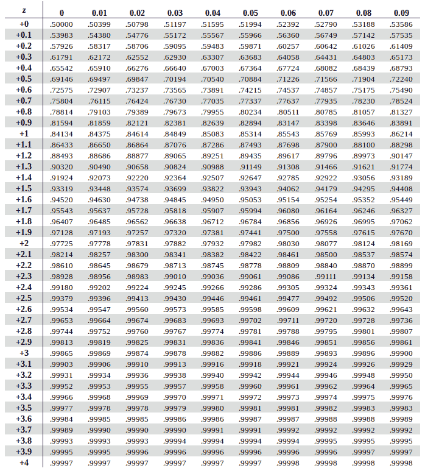

Image Source: https://www.ztable.net/

$$1+0.96=1.96$$

Look for $Z_0$

$$Z_0 = \frac{\bar{x} - \mu_0}{\sigma/\sqrt{n}}$$

$$Z_0 = \frac{40.5 - 40}{1.25/\sqrt{10}}$$

$$Z_0 = 1.2649 \approx 1.26$$
$$1.26 < 1.96$$

$$Z_0 < Z_{value}$$

*Therefore, we accept* $H_0$

Use $Z_0 = 1.26$ in the table

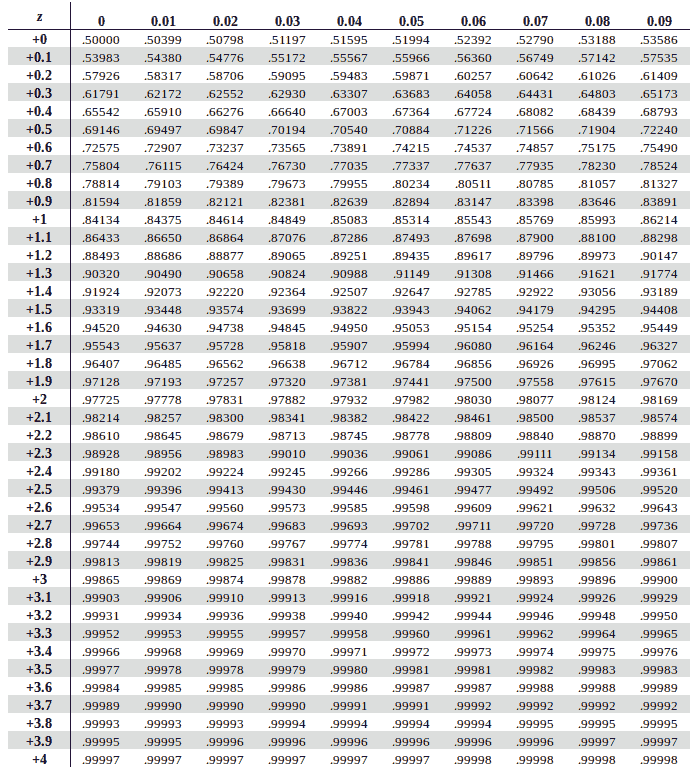

Image Source: https://www.ztable.net/

$$z^2 = 0.8962$$

Look for the *P-Value*

$$P = 1 - z^2 = 1 - 0.8962$$

$$P = 0.1038$$

$$P_{value} = 2(0.1038) = 0.2076$$

$$0.2076 > 0.05$$

$$P_{Value} > \alpha$$

*Therefore, we accept* $H_0$

## B. What is the P-value for the test in part A?

*This was already answered in part A.*

$$P = 1 - z^2 = 1 - 0.8962$$

$$P = 0.1038$$

**Final Answer:**

$$P_{value} = 2(0.1038) = 0.2076$$

## C. What is the β-error for the test in part B if the true mean life is 42 hours?

*If* $\mu_2 = 42$

$\mu_1 = 40$

$\bar{x}_1 = 40.5$

$$\bar{x}_1 - \mu_1 = 40.5 - 40$$

$$\bar{x}_1 - \mu_1 = 0.5$$

$$\bar{x}_2 = 41.5$$

$$Z_1 = \frac{\bar{x}_1 - \mu_2 }{\sigma / \sqrt{n}}$$

$$Z_1 = \frac{40.5 - 42}{1.25 / \sqrt{10}}$$

$$Z_1 = -3.7947 \approx -3.79$$

$$Z_2 = \frac{\bar{x}_2 - \mu_2}{\sigma / \sqrt{n}}$$

$$Z_2 = \frac{41.5 - 42}{1.25 / \sqrt{10}}$$

$$Z_2 = -1.2649 \approx -1.26$$

$$Z_1 = -3.79 = -3.7 + (-0.09)$$

$$Z_2 = -1.26 = -1.2 + (-0.06)$$

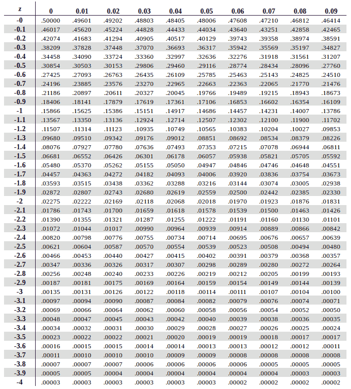

Image Source: https://www.ztable.net/

$Z^2_1 = 0.00008$

$Z^2_2 = 0.10383$

$$\beta = P(Z_1 < z < Z_2)$$

$$\beta = P(-3.7947 < z < -1.2649)$$

$$\beta = P(-3.7947 < z < -1.2649)$$

$$\beta = 0.10383 - 0.00008$$

**Final Answer:**

$$\beta = 0.10375 \approx 0.1038$$

## D. What sample size would be required to ensure that β does not exceed 0.10 if the true mean is 44 hours?

*If* $\mu = 44$

$$\beta = Z^2_4 = Z^2_3$$

Use two *Z* values in which their respective $Z^2$ will have a difference that is less than 0.10.

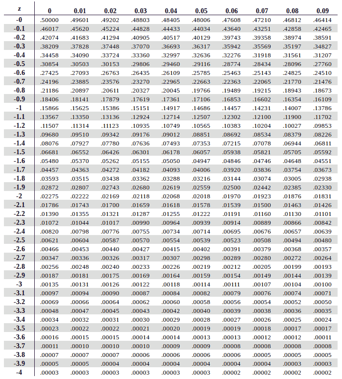

Image Source: https://www.ztable.net/

$$Z_3 = -2.43 = -2.4 + (-0.03)$$

$$Z^2_3 = 0.00755$$

$$Z_4 = -1.24= -1.2 + (-0.04)$$

$$Z^2_4 = 0.10749$$

$$\beta = 0.10749 - 0.00755$$

$$\beta = 0.09994$$

$$Z = \frac{\bar{x}-44}{1.25/\sqrt{n}}$$

$$-2.43 = \frac{43.5-44}{1.25/\sqrt{n}}$$

$$\frac{\sqrt{n}(43.5-44)}{1.25} = -2.43$$

$$\frac{\sqrt{n}(-0.5)}{1.25} = -2.43$$

$$\sqrt{n} = 6.075$$

$$n = 36.91$$

**Final Answer:**

$$n \approx 37$$

## E. Explain how you could answer the question in part A by calculating an appropriate confidence bound on battery life.

*This was already answered in part A … again.*

$$\alpha = 0.05$$

$$C = 1 - \alpha = 1 - 0.05$$

**Final Answer:**

$$C = 0.95$$